# Water quality testing

Molly Wilson

2024-05-10

### Set-up code

#### Importing, cleaning, and merging datasets

```r
# import data
sites <- read_excel(here("water_quality", "data_raw", "Water quality data.xlsx"), sheet = "sites") %>%
  clean_names()

ysi <- read_excel(here("water_quality", "data_raw", "Water quality data.xlsx"), sheet = "ysi") %>%
  rename_with(tolower) %>% # prevents clean_names() from adding extra underscores before caps
  clean_names() %>%
  mutate(site_code = if_else(site_code == "Corington", "COV",
                             if_else(site_code == "greenhEB", "GEB",
                                     site_code
                               ))) %>%
  rename(site_code_depth = site_code) %>%
  filter(as.character(date) != "2023-10-05" # removing incomplete/aborted day
          & as.character(time) %nin%    c("1899-12-31 11:38:13",    "1899-12-31 14:45:28", "1899-12-31 09:41:43", "1899-12-31 09:29:43", "1899-12-31 10:36:28", "1899-12-31 12:55:39", "1899-12-31 14:20:21")) # removing duplicate samples

entero <- read_excel(here("water_quality", "data_raw", "Water quality data.xlsx"), sheet = "enterococcus") %>%
  clean_names()

boats <- read_excel(here("water_quality", "data_raw", "Water quality data.xlsx"), sheet = "boat activity") %>%
  clean_names() %>%
  mutate(site_code = if_else(site_code == "GIA/LBI", "GIA", site_code)) # coding merged GIA/LBI sites as GIA for now

precip <- read_excel(here("water_quality", "data_raw", "Water quality data.xlsx"), sheet = "precipitation") %>%
  clean_names() %>%
  right_join(data.frame(date = seq(ymd('2023-10-10'), as.Date(today()), by='day'))) %>%
  mutate(precipitation_in = replace_na(precipitation_in, 0))

# merge site, ysi, enterococcus, boat, and precipitation data into one dataset
wq_data <- ysi %>%
  select(date, site_code_depth, temperature_c = temperature_c_24, ph, do_mg_l, do_percent_sat, conductivity_us_cm, sal_psu, phycoerythrin_rfu, chlorophyll_rfu) %>%
  drop_na() %>%
  left_join(ysi %>%
              select(date, site_code_depth, turbidity_fnu) %>%
              drop_na(),
            by = c("date", "site_code_depth")) %>%
  mutate(site_code = str_replace(site_code_depth, "[:digit:]", ""),
         depth_m = parse_number(site_code_depth),
         depth_m = replace_na(depth_m, 1)) %>% # surface-only sites are assumed to be approx 1m
  left_join(sites, by = c("site_code")) %>%
  left_join(entero, by = c("date", "site_code")) %>%
  left_join(boats, by = c("date", "site_code")) %>%
  mutate(n_colonies = replace_na(n_colonies, 0),
         entero_yn = if_else(n_colonies == 0, "Absent",
                             if_else(n_colonies > 0, "Present", "NA")),
         n_boats = replace_na(n_boats, 0),
         month = month(ymd(date), label = TRUE),
         year = year(ymd(date)),
         date_label = paste(as.character(month), as.character(year)),
         date_label = if_else(as.character(date) == "2024-04-29", "May 2024", date_label),
         date_cat = if_else(substr(date_label, 1, 3) %in% c("Dec", "Jan", "Feb", "Mar", "Apr"), "High season", "Low season"),
         site_cat = if_else(site_code %in% c("YIE", "GIE"), "Control", "Treatment")) %>%
  select(date, date_label, date_cat, site_code_depth, site_code, depth_m, site_name, site_cat, latitude, longitude, n_boats, temperature_c, ph, do_mg_l, do_percent_sat, conductivity_us_cm, sal_psu, phycoerythrin_rfu, chlorophyll_rfu, turbidity_fnu, n_colonies, entero_yn) %>%
  distinct()

# streamlining data for graphs to include only regularly monitored sites at 1m depth
data_mon <- wq_data %>%
  filter(site_code %in% c("NBRB", "NBRM", "EC", "NBA", "LBI", "GIA", "ML", "RBA", "GOE", "TPBN", "GIE", "YIE", "DB", "MRCH", "COV", "GEB", "FHB", "YIN", "BDB", "LDB", "MRYC", "EBB", "EBBW") & depth_m == 1) %>% # GEB and COV currently combined as Exchange Bay - Club Hotel, also omitting YRS, RRS
  mutate(site_name = factor(site_name, levels = c("Emerald Cove",
                                                  "Nonsuch Bay Resort Mangrove",
                                                  "Nonsuch Bay Resort Beach",
                                                  "Nonsuch Bay Anchorage",
                                                  "Little Bird Island",
                                                  "Green Island Anchorage",
                                                  "Mill Reef Yacht Club",
                                                  "Macy Ledge",
                                                  "Ricketts Bay Anchorage",
                                                  "Garden of Eden",
                                                  "Ten Pound Bay Nursery",
                                                  "Little Deep Bay",
                                                  "Big Deep Bay",
                                                  "York Island Nursery",
                                                  "Friars Head Bay",
                                                  "Exchange Bay - Dansby",
                                                  "Exchange Bay - MRC Hotel",
                                                  "Exchange Bay - Boom E",
                                                  "Exchange Bay - Boom W",
                                                  "Offshore - Green Island E",
                                                  "Offshore - York Island E"))) %>%
  mutate(site_name = fct_rev(site_name)) # flipped axis plot needs reversed order

# test for sites/depths where multiple samples were taken
test_duplicates <- data_mon %>%
  group_by(date, site_code, depth_m) %>%
  summarize(count = n()) %>%
  filter(count > 1)
```

##### Setting target references, plotting ranges, and parameter labels for graphs

```r
# pH
lab_ph <- "pH"
ref_ph = data.frame(xmin = -Inf, xmax = Inf, ymin = 7.7, ymax = 8.5)
lab_ref_ph <- "Target range (Rogers et al. 2001)"
ylims_ph <- c((min(data_mon$ph, na.rm = T) - .7), 9)

# turbidity
lab_turb <- "Turbidity (FNU)"
ref_turb = data.frame(xmin = -Inf, xmax = Inf, ymin = 0, ymax = 2)
lab_ref_turb <- "Target range (EPA)"
ylims_turb <- c((min(data_mon$turbidity_fnu, na.rm = T) - 1), (max(data_mon$turbidity_fnu, na.rm = T) + 1))

# do
lab_do <- expression("Dissolved oxygen (mg "*L^-1*")")
ref_do = data.frame(xmin = -Inf, xmax = Inf, ymin = 6, ymax = Inf)
lab_ref_do <- "Target range (EPMA 2019)"
ylims_do <- c((min(data_mon$do_mg_l, na.rm = T) - 1), (max(data_mon$do_mg_l, na.rm = T) + 1))

# temp
lab_temp <- expression("Temperature ("*~degree*C*")")
ref_temp = data.frame(xmin = -Inf, xmax = Inf, ymin = 23, ymax = 29.6)
lab_ref_temp <- "Target range (Coral Reef Alliance)"
ref_temp_bleaching = 30.63
lab_ref_temp_bleaching <- "Coral bleaching threshold (NOAA)"
ylims_temp <- c(22, (max(data_mon$temperature_c, na.rm = T) + 1))

# enterococcus
lab_entero <- expression(paste(italic("Enterococcus" ), " spp. (colonies "*mL^-1*")"))
ref_entero = data.frame(xmin = -Inf, xmax = Inf, ymin = 0, ymax = 7/100) # below 7/100mL (EPA)
lab_ref_entero <- "Target range (EPA)"
ylims_entero <- c(0, (max(data_mon$n_colonies, na.rm = T) + 10))

# phycoerythrin
lab_phyco <- "Phycoerythrin (RFU)"
ylims_phyco <- c((min(data_mon$phycoerythrin_rfu, na.rm = T) - 1), (max(data_mon$phycoerythrin_rfu, na.rm = T) + 1))

# chlorophyll a
lab_chlor <- expression(paste("Chlorophyll ", italic("a")))
ylims_chlor <- c((min(data_mon$chlorophyll_rfu, na.rm = T) - 1), (max(data_mon$chlorophyll_rfu, na.rm = T) + 1))

# aesthetics for reference rectangles
c_range <- "gray20" # setting color for target range in graphs
a_range <- 0.2 # setting alpha (transparency) for target range in graphs
```

#### Writing functions for graph types

```r
# flipped point plots by site, with and without reference boxes

flpoint_site <- function(data_wq, y, ylab, ylims) {
  ggplot() +
    geom_point(data = data_wq,
             aes(site_name, {{y}}),
             alpha = 0.6) +
    labs(x = "", y = ylab) +
    ylim(ylims) +
    theme_bw() +
    coord_flip()
}

flpoint_site_ref <- function(ref_data, data_wq, y, ylab, ylims) {
  ggplot() +
    geom_rect(data = ref_data,
              aes(xmin = xmin, xmax = xmax, ymin = ymin, ymax = ymax, fill = "What"),
              alpha = a_range) +
    scale_fill_manual(values = c_range, guide = "none") +
    geom_point(data = data_wq,
             aes(site_name, {{y}}),
             alpha = 0.6) +
    labs(x = "", y = ylab) +
    ylim(ylims) +
    theme_bw() +
    coord_flip()
}

# line plots over time, with and without reference boxes

line_time <- function(data_wq, y, ylab, ylims) {
  ggplot() +
    geom_line(data = data_wq %>%
                filter(site_cat == "Treatment"),
            aes(x = date, y = {{y}}, group = site_code),
            color = "lightblue",
            alpha = 0.9) +
    geom_point(data = data_wq %>%
                filter(site_cat == "Treatment"),
            aes(x = date, y = {{y}}, group = site_code),
            color = "lightblue",
            alpha = 0.9) +
    geom_line(data = data_wq %>%
                filter(site_cat == "Control"),
            aes(x = date, y = {{y}}, group = site_code),
            color = "black",
            alpha = 0.9) +
    geom_point(data = data_wq %>%
                filter(site_cat == "Control"),
            aes(x = date, y = {{y}}, group = site_code),
            color = "black",
            alpha = 0.9) +
    scale_x_datetime(date_breaks = "2 months",
                   date_labels = "%b %Y") +
    labs(x = "", y = ylab, color = "") +
    ylim(ylims) +
    theme_bw() +
    theme(legend.position = "top")
}

line_time_ref <- function(data_ref, lab_ref, data_wq, y, ylab, ylims) {
  ggplot() +
    geom_rect(data = data_ref,
              aes(xmin = as.POSIXct(-Inf), xmax = as.POSIXct(Inf), ymin = ymin, ymax = ymax, fill = lab_ref),
              alpha = a_range) +
    scale_fill_manual(values = c_range) +
    geom_line(data = data_wq %>%
                filter(site_cat == "Treatment"),
            aes(x = date, y = {{y}}, group = site_code),
            color = "lightblue",
            alpha = 0.9) +
    geom_point(data = data_wq %>%
                filter(site_cat == "Treatment"),
            aes(x = date, y = {{y}}, group = site_code),
            color = "lightblue",
            alpha = 0.9) +
    geom_line(data = data_wq %>%
                filter(site_cat == "Control"),
            aes(x = date, y = {{y}}, group = site_code),
            color = "black",
            alpha = 0.9) +
    geom_point(data = data_wq %>%
                filter(site_cat == "Control"),
            aes(x = date, y = {{y}}, group = site_code),
            color = "black",
            alpha = 0.9) +
    scale_x_datetime(date_breaks = "2 months",
                   date_labels = "%b %Y") +
    labs(x = "", y = ylab, fill = "", color = "") +
    ylim(ylims) +
    theme_bw() +
    theme(legend.position = "top")
}
```

### Plotting standard graphs by parameter

#### Questions:

- How do we want to label control (offshore) vs. treatment sites?
- Should we be calling “Exchange Bay - Dansby” -> “Exchange Bay - Turtle Beach” for political reasons?

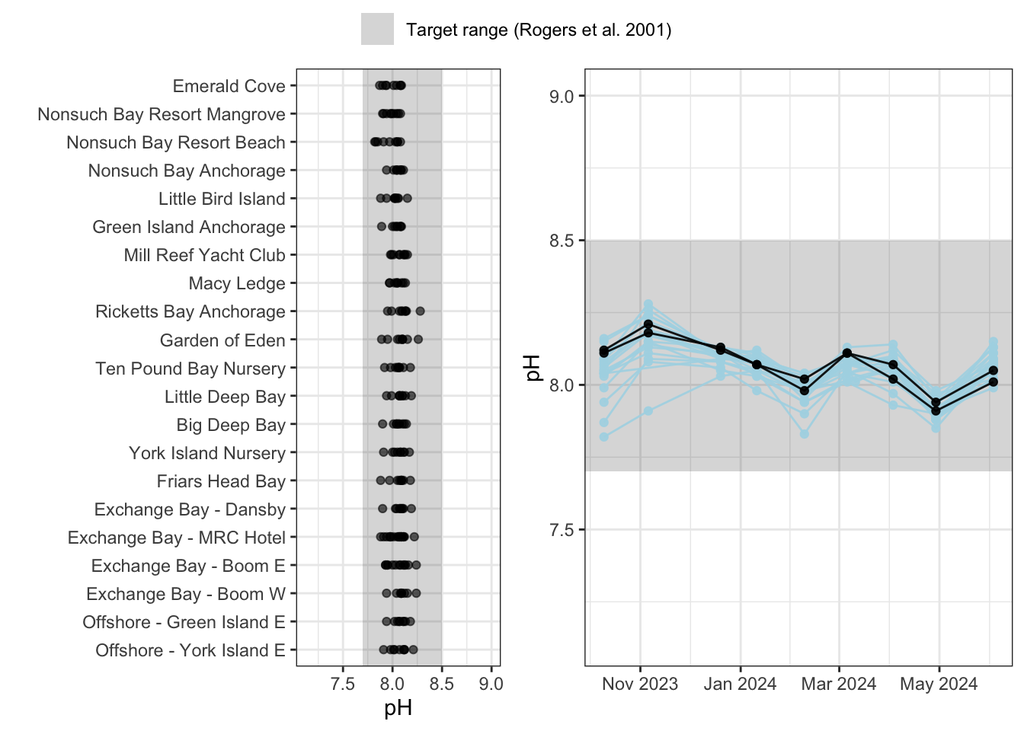

```r
# ph
ph_point <- flpoint_site_ref(ref_ph, data_mon, ph, lab_ph, ylims_ph)
ph_line <- line_time_ref(ref_ph, lab_ref_ph, data_mon, ph, lab_ph, ylims_ph)

ggarrange(ph_point, ph_line,
          ncol = 2, nrow = 1, common.legend = TRUE, legend = "top")
```

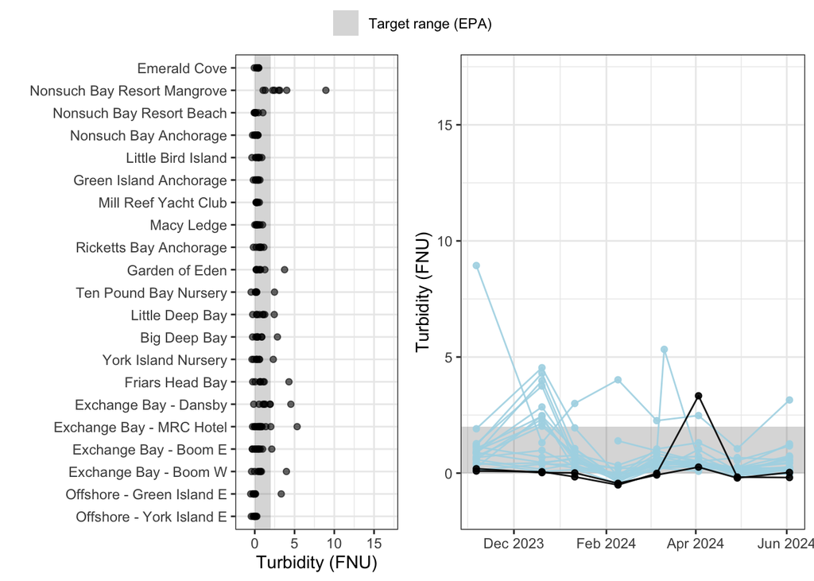

```r
ggsave(here("water_quality", "figs", "2023-2024", "ph.png"),  width = 10, height = 6)

# turbidity
turb_point <- flpoint_site_ref(ref_turb, filter(data_mon, as.character(date) != "2023-10-10"), turbidity_fnu, lab_turb, ylims_turb) # removing first date, calibration was off
turb_line <- line_time_ref(ref_turb, lab_ref_turb, filter(data_mon, as.character(date) != "2023-10-10"), turbidity_fnu, lab_turb, ylims_turb)

ggarrange(turb_point, turb_line,
          ncol = 2, nrow = 1, common.legend = TRUE, legend = "top")
```

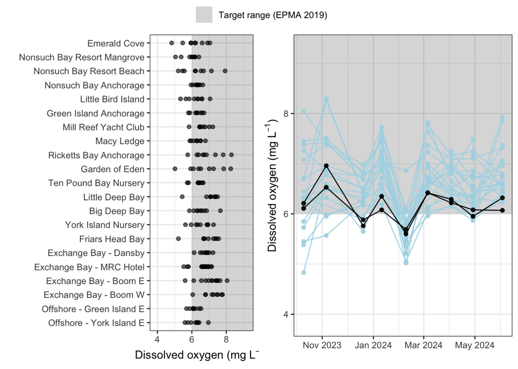

```r
ggsave(here("water_quality", "figs", "2023-2024", "turbidity.png"),  width = 10, height = 6)

# do
do_point <- flpoint_site_ref(ref_do, data_mon, do_mg_l, lab_do, ylims_do)
do_line <- line_time_ref(ref_do, lab_ref_do, data_mon, do_mg_l, lab_do, ylims_do)

ggarrange(do_point, do_line,
          ncol = 2, nrow = 1, common.legend = TRUE, legend = "top")
```

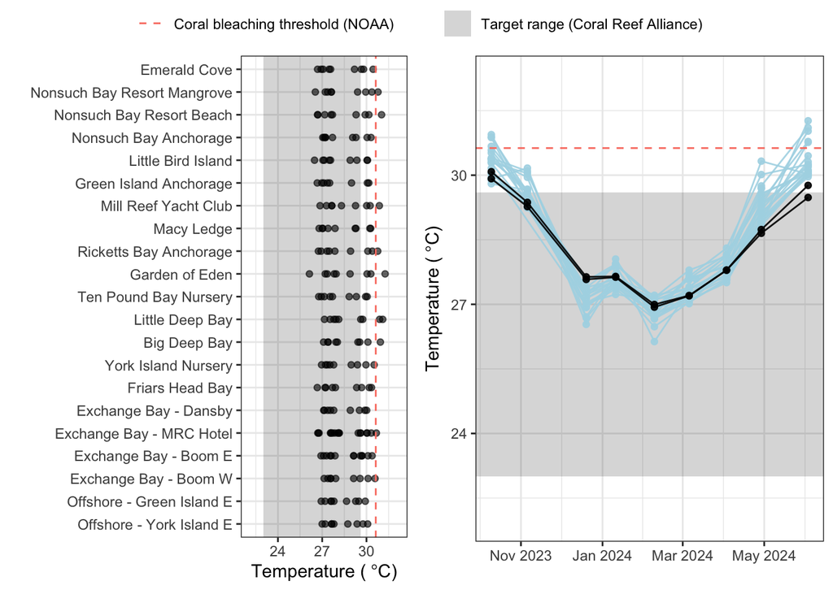

```r
ggsave(here("water_quality", "figs", "2023-2024", "do.png"),  width = 10, height = 6)

# temp
temp_point <- flpoint_site_ref(ref_temp, data_mon, temperature_c, lab_temp, ylims_temp) +
  geom_hline(yintercept = ref_temp_bleaching, color = "salmon", linetype = "dashed")
temp_line <- line_time_ref(ref_temp, lab_ref_temp, data_mon, temperature_c, lab_temp, ylims_temp) +
  geom_hline(aes(yintercept = ref_temp_bleaching, linetype = lab_ref_temp_bleaching),
             color = "salmon") +
  scale_linetype_manual(values = "dashed", name = "")

ggarrange(temp_point, temp_line,
          ncol = 2, nrow = 1, common.legend = TRUE, legend = "top")
```

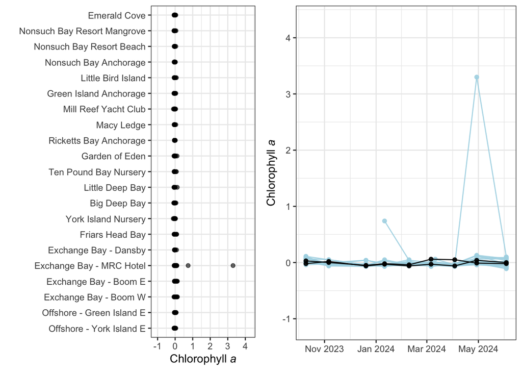

```r
ggsave(here("water_quality", "figs", "2023-2024", "temp.png"),  width = 10, height = 6)

# chlorophyll a
chlor_point <- flpoint_site(data_mon, chlorophyll_rfu, lab_chlor, ylims_chlor)
chlor_line <- line_time(data_mon, chlorophyll_rfu, lab_chlor, ylims_chlor)

ggarrange(chlor_point, chlor_line,
          ncol = 2, nrow = 1, common.legend = TRUE, legend = "top")
```

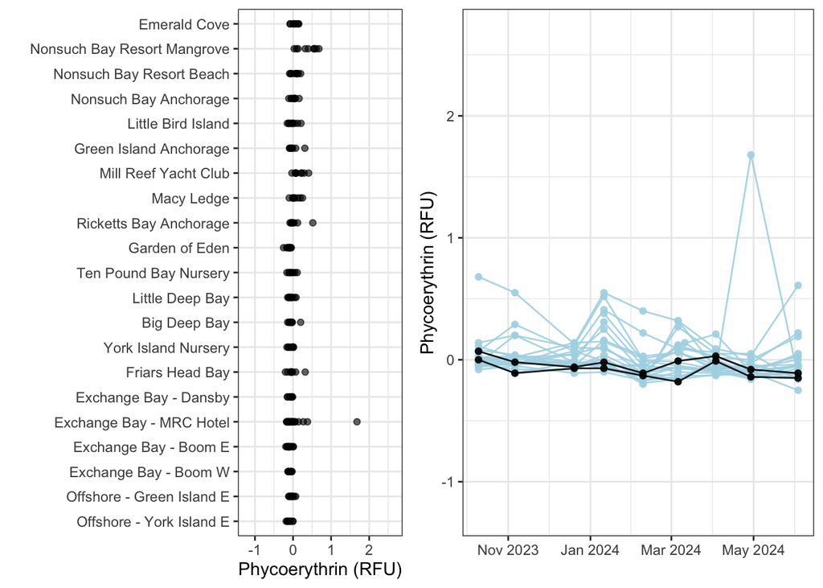

```r
ggsave(here("water_quality", "figs", "2023-2024", "chlor.png"),  width = 10, height = 6)

# phycoerythrin
phyco_point <- flpoint_site(data_mon, phycoerythrin_rfu, lab_phyco, ylims_phyco)
phyco_line <- line_time(data_mon, phycoerythrin_rfu, lab_phyco, ylims_phyco)

ggarrange(phyco_point, phyco_line,
          ncol = 2, nrow = 1, common.legend = TRUE, legend = "top")
```

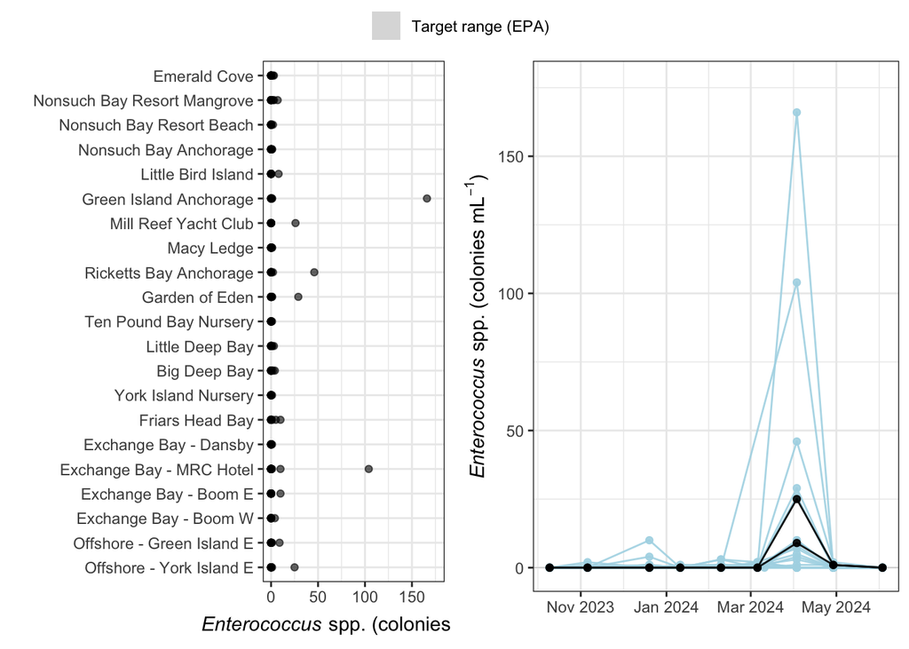

```r
ggsave(here("water_quality", "figs", "2023-2024", "phyco.png"),  width = 10, height = 6)

# enterococcus
entero_point <- flpoint_site_ref(ref_entero, data_mon, n_colonies, lab_entero, ylims_entero)
entero_line <- line_time_ref(ref_entero, lab_ref_entero, data_mon, n_colonies, lab_entero, ylims_entero)

ggarrange(entero_point, entero_line,
          ncol = 2, nrow = 1, common.legend = TRUE, legend = "top")
```

```r
ggsave(here("water_quality", "figs", "2023-2024", "entero.png"),  width = 10, height = 6)
```

### Map play

Currently **Enterococcus** spp. only, but could potentially look at phycoerythrin/chlorophyll (its just less dramatic and I don’t want to overwhelm people with graphs)

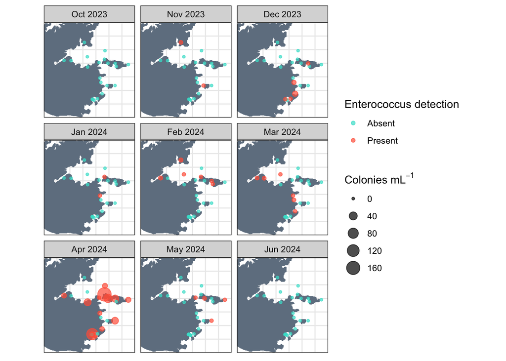

```r
# Antigua shapefile
atg <- st_read(here("mapping", "shapefiles", "atg_adm_2019_shp", "atg_admbnda_adm1_2019.shp")) %>%
  st_union() %>%
  st_sf()
# set lat/lon for graph (map) boundaries
lons = c(-61.72, -61.65)
lats = c(17.03, 17.10)

ggplot() +
  geom_sf(data = atg, fill = "slategray", color = "slategray") + # ATG basemap
  coord_sf(xlim = lons, ylim = lats, expand = FALSE) + # setting map boundaries
  geom_point(data_mon,
             mapping = aes(x = longitude, y = latitude, color = entero_yn, size = n_colonies),
             alpha = 0.7) + # add sites
  scale_color_manual(values = c("turquoise", "tomato")) +
  facet_wrap(. ~ factor(date_label, levels = c("Oct 2023", "Nov 2023", "Dec 2023", "Jan 2024", "Feb 2024", "Mar 2024", "Apr 2024", "May 2024", "Jun 2024"))) +
  labs(size = expression("Colonies "*mL^-1),
       color = "Enterococcus detection") +
  theme_bw() +
  theme(axis.title = element_blank(),
        axis.text = element_blank(),
        axis.ticks = element_blank())
```

```r
ggsave(here("water_quality", "figs", "2023-2024", "entero_map.png"), width = 10, height = 8)
```

### Boat play

There are some incidences of high boat numbers and high enterococcus numbers (top right), but definitely some exceptions (bottom right). Is this worth including?

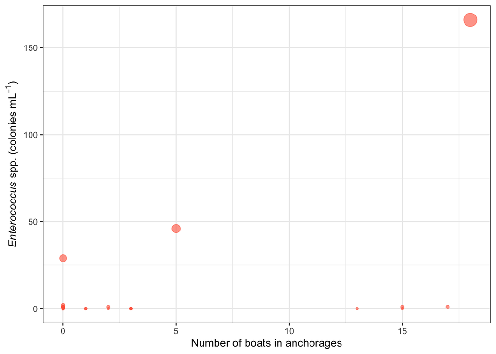

```r
ggplot(data_mon %>% filter(site_code %in% c("GIA", "RBA", "NBA", "GOE")),
       aes(x = n_boats, y = n_colonies, size = n_colonies)) +
  geom_point(color = "tomato", alpha = 0.6) +
  labs(x = "Number of boats in anchorages", y = expression(paste(italic("Enterococcus" ), " spp. (colonies "*mL^-1*")"))) +
  theme_bw() +
  theme(legend.position = "none")
```

### Precipitation

Didn’t find much relationship between precipitation and any parameters at this point, it will be helpful to have more data over time. Including exploratory graphs at this point for reference.

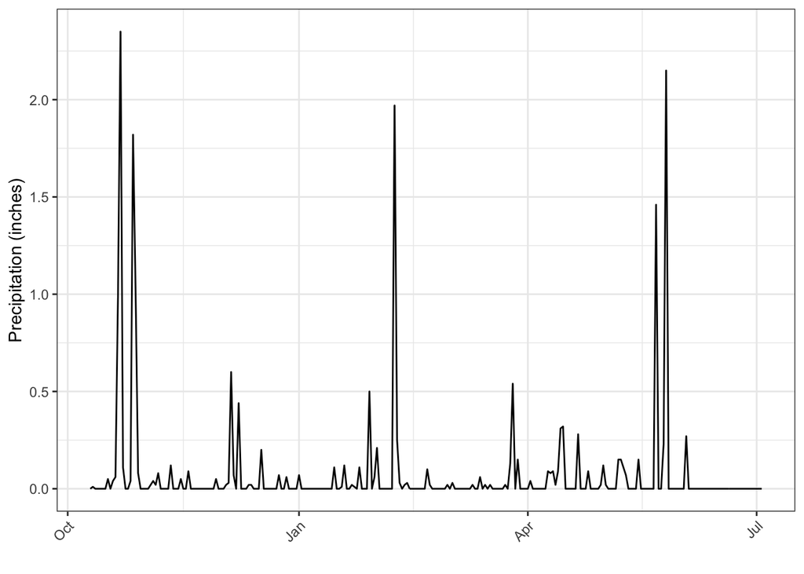

```r
ggplot() +
  geom_line(data = precip,
             aes(x = date, y = precipitation_in)) +
  labs(x = "", y = "Precipitation (inches)") +
  theme_bw() +
  theme(axis.text.x = element_text(angle = 45, hjust = 1))
```

```r
# trying to calculate the amount of rainfall preceding a testing day
ysi_dates <- ysi %>%
  select(date) %>%
  distinct() # need to clarify which dates were actual monitoring days

precip_wk <- ysi %>%
  select(end_date = date) %>%
  distinct() %>%
  mutate(start_date = end_date - days(7)) %>%
  mutate(period = interval(ymd(start_date), ymd(end_date))) %>% # find a way to label this
  fuzzy_left_join(precip, by = c("start_date" = "date", "end_date" = "date"),
                          match_fun = list(`<=`, `>=`)) %>%
  group_by(period) %>%
  summarize(precip_wkprior = sum(precipitation_in))

precip_48hr <- ysi %>%
  select(end_date = date) %>%
  distinct() %>%
  mutate(start_date = end_date - days(2)) %>%
  mutate(period = interval(ymd(start_date), ymd(end_date))) %>% # find a way to label this
  fuzzy_left_join(precip, by = c("start_date" = "date", "end_date" = "date"),
                          match_fun = list(`<=`, `>=`)) %>%
  group_by(period) %>%
  summarize(precip_wkprior = sum(precipitation_in))
```

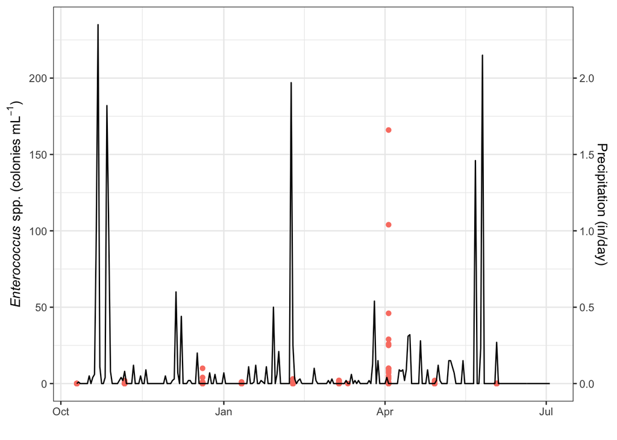

```r
# dual y attempts

scale = .01 # relates y axis 1 with y axis 2

point_precip <- function(data, y, ylab, scale) {
  ggplot() +
    geom_point(data = data,
               aes(x = date, y = {{y}}),
               color = "salmon") +
    geom_line(data = precip,
               aes(x = date, y = precipitation_in/scale),
              color = "black") +
    scale_y_continuous(
      name = ylab,
      sec.axis = sec_axis(~.*scale, name = "Precipitation (in/day)")
  ) +
    labs(x = "") +
    theme_bw()
}

point_precip(data_mon, n_colonies, lab_entero, 0.01)
```

### Sargassum play

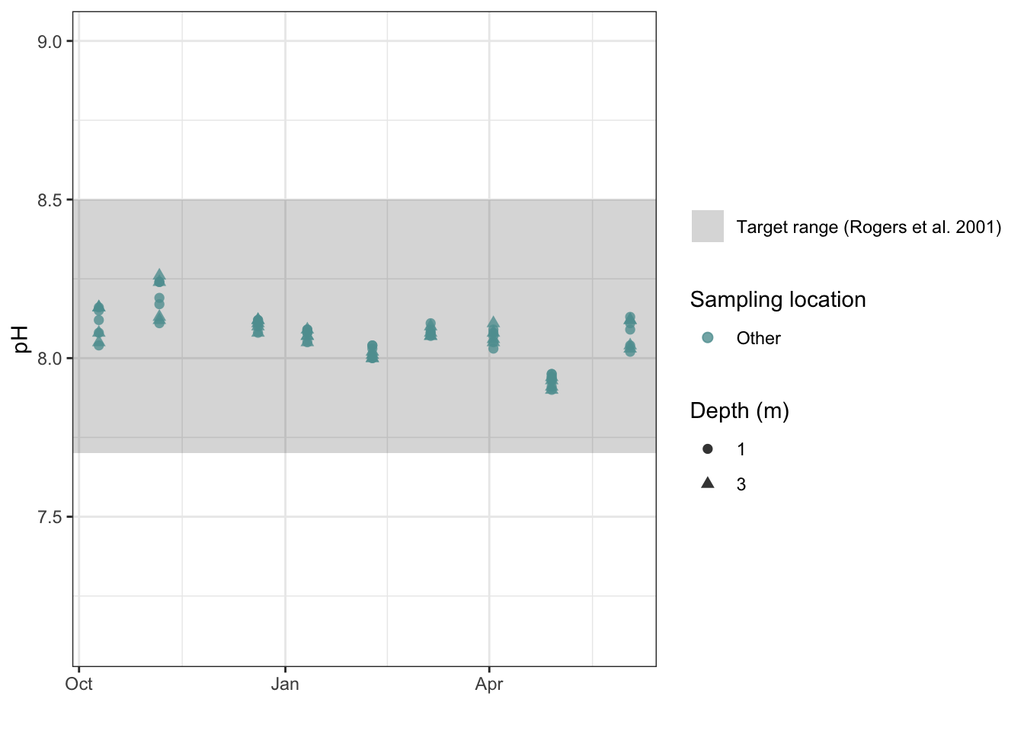

```r
sites_sarg <- c("EBB", "EBBW", "YIN", "NBA", "DB")

sarg <- function(data_ref, lab_ref, y, ylab, ylims) {
  ggplot() +
    geom_rect(data = data_ref,
              aes(xmin = as.POSIXct(-Inf), xmax = as.POSIXct(Inf), ymin = ymin, ymax = ymax, fill = lab_ref),
              alpha = a_range) +
    scale_fill_manual(values = c_range) +
    geom_point(data = wq_data %>%
                 filter(site_code %in% sites_sarg) %>%
                 mutate(site_cat = if_else(site_cat == "Boom", "Seaweed boom", "Other")),
       aes(x = date, y = {{y}}, color = site_cat, shape = as.character(depth_m)),
       alpha = 0.8, size = 2) +
    scale_color_manual(values = c("cadetblue", "orange")) +
    ylim(ylims) +
    labs(x = "", y = ylab, shape = "Depth (m)", color = "Sampling location", fill = "") +
    theme_bw()
}

sarg(ref_ph, lab_ref_ph, ph, lab_ph, ylims_ph)
```

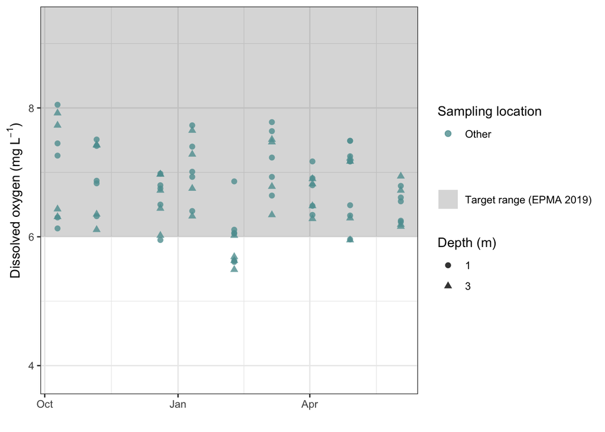

```r
sarg(ref_do, lab_ref_do, do_mg_l, lab_do, ylims_do)
```

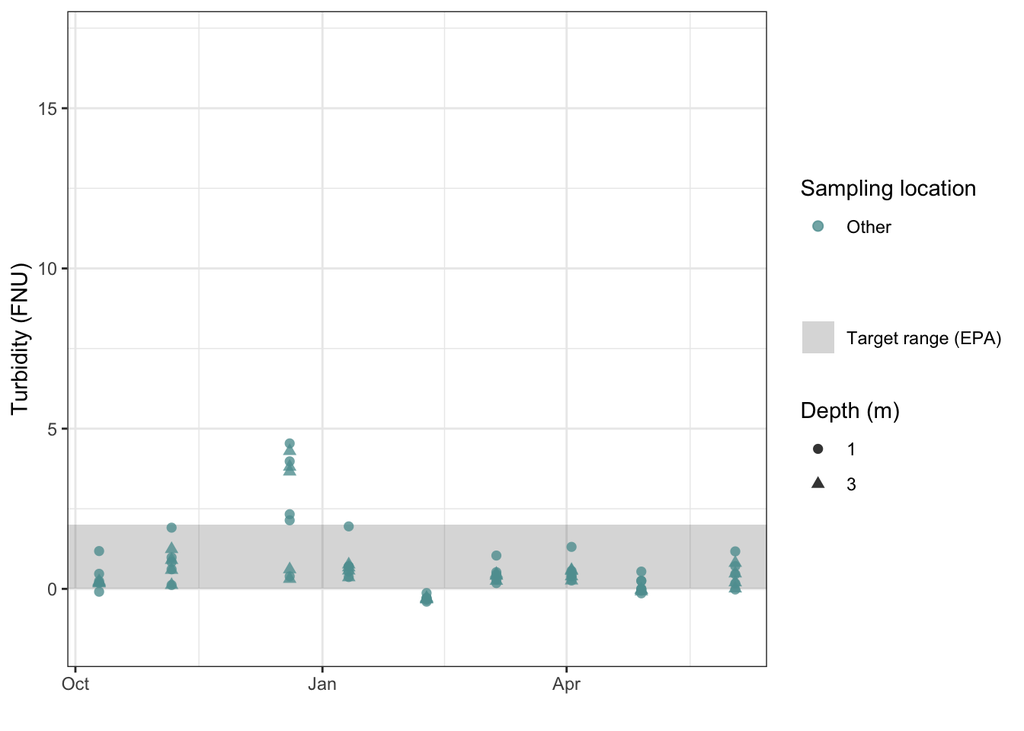

```r
sarg(ref_turb, lab_ref_turb, turbidity_fnu, lab_turb, ylims_turb)
```

```r
# sarg(ref_entero, lab_ref_entero, n_colonies, lab_entero, ylims_entero)
```